# TIL6022 Project Group 18

# How did oil prices affect logistics performance in The Netherlands between 2021 and 2023

Members: **Adi Putra Rukmananda$^{a}$, Anh Tran$^{b}$, Fakhrinanisa Islah Birru$^{c}$, Rifan Fauzan Ghofir$^{d}$, and Wilona Septyola Br Surbakti$^{e}$**

Student Numbers: *$^{a}$5942365, $^{b}$6191282, $^{c}$5131014, $^{d}$5347076, $^{e}$6270069*

## Introduction

As the third largest oil producer (**[U.S Energy Information Administration, 2022](https://www.eia.gov/international/rankings/world)**), Russia has a big influence towards the global oil price. The geopolitical landscape, especially with the on-going war between Russia and Ukraine, has further strengthened this impact. On February 24, 2022, Russia announced special military action against Ukraine, and the Russia–Ukraine war broke out. As a result to the war, Ukraine imposed a ban on natural gas and oil exports in February 2024 (**[Gas Transmission System Operator of Ukraine, 2022](https://tsoua.com/en/news/ukraine-stops-exporting-natural-gas/)**), followed by a number of sanctions by EU countries in response to Russia’s war of aggression (**[EU Sanction on Russia, 2022](https://www.consilium.europa.eu/en/policies/eu-response-ukraine-invasion/)**), intensifying the energy crisis in Europe and leading to fluctuated change in oil prices.

The Netherlands, as a key logistics hub in Europe and heavily dependent on fuel for its freight and transportation operations, was impacted by the fluctuating oil prices caused by these geopolitical developments. The main objective of this research is to see the impact and correlation between the change of oil prices on the logistics performance in the Netherlands before and after the Russia-Ukraine energy dispute in 2022.

## Research Questions and Objectives

The main research question for this project is **how did oil prices affect logistics performance in The Netherlands between 2021 and 2023?**

Following are the sub research questions of this project:

1. How did the fluctuation in oil prices impact the total freight volume (ton) trend in the Netherlands between 2021 and 2023?
2. How did the fluctuation in oil prices impact the volume (ton) of freight transported in different transport modes in the Netherlands between 2021 and 2023?
3. How did the total export value (USD thousand) from the Netherlands to EU countries and total import value (USD thousand) from the EU countries to the Netherlands fluctuate in response to changes in oil prices between 2021 and 2023?

The objectives of this project are:

1. To visualize and examine the impact of oil price fluctuation on the changes in total freight volume (ton) in the Netherlands between 2021 and 2023.
2. To visualize, compare, and determine the correlation between oil price fluctuations and the volume of freight transported across different modes of transportation (air, rail, inland waterway, sea, and road) in the Netherlands between 2021 and 2023.
3. To visualize, sort, and compare the fluctuations in the total export value (USD thousand) from the Netherlands to five EU countries and total import value (USD thousand) from the five EU countries to the Netherlands fluctuate in response to changes in oil prices between 2021 and 2023.

Timescale:  
For conducting analysis, we use quarterly data from 2021 until 2023.

Spatial scale:  
The analysis will focuses on the Netherlands. The international trade data will focuses on top 5 countries with highest trade value with the Netherlands.

## Data Pipeline

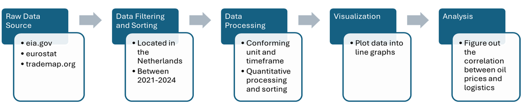

## 1. Oil Price Surge

Starting in 2021, oil prices showed a consistent upward trajectory, climbing steadily from USD 60.82 to USD 79.59, marking a significant 30.9% increase over the year. However, 2022 emerged as a particularly turbulent year with dramatic price fluctuations. Prices surged to a peak of USD 113.54 in Q2 2022, representing the highest point in the three-year period, before beginning a steady decline. This volatility is attributed to global supply chain disruptions, particularly supply losses and dislocations stemming from the Russia-Ukraine conflict, which significantly affected global oil prices during this period.

Moving into 2023, oil prices eased and the market showed signs of stabilization. This aligns with research by Huang et al. (2017), which found that geopolitical factors typically have only a short-term impact (approximately up to 10 months) on oil prices. While Q1 2023 prices (USD 81.17) were lower than the same period in 2022 (USD 100.30), they remained substantially higher than 2021 levels (USD 60.82), suggesting a new price threshold had been established.

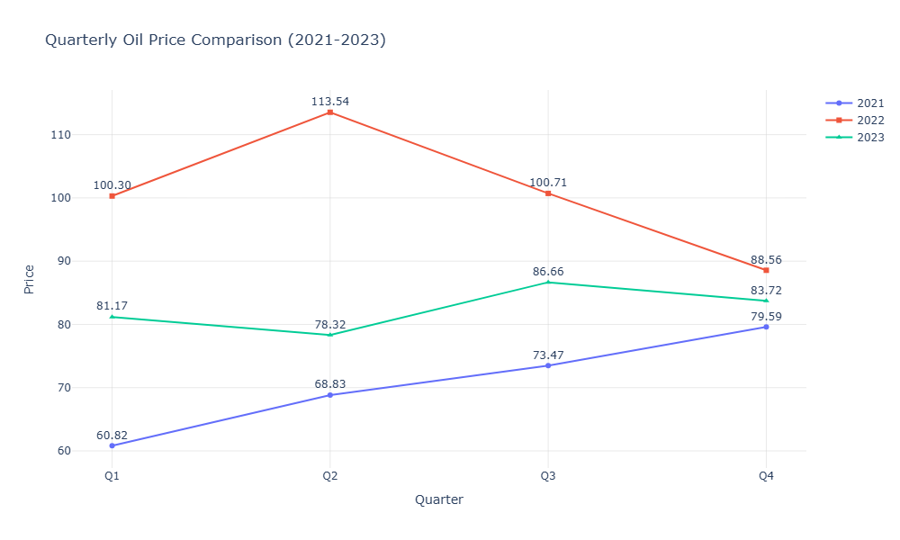

Oil price data is obtained from (**[U.S Energy Information Administration, 2022](https://www.eia.gov/international/rankings/world)**), specifically for the Europe Brent Spot Price Free on Board (FOB) measured in USD Dollar per Barrel.

## 2. Impact on The Netherland’s Logistic Performance

## A. Oil Price and Shipment Quantity Trends from 2021 to 2023

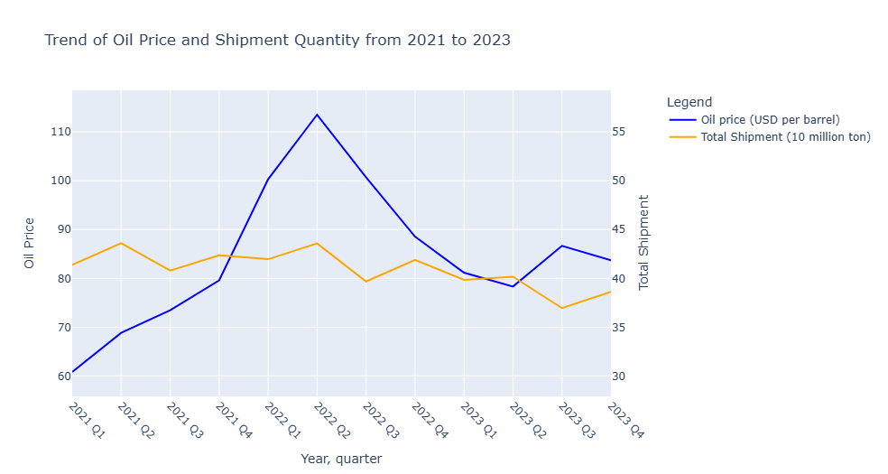

The scatter plot examining the relationship between oil prices and total shipment volumes reveals a weak positive correlation. The nearly flat line of best fit suggests that changes in oil prices have minimal direct impact on shipment volumes. The wide confidence interval (shown by the shaded area) indicates high uncertainty in this relationship. The scattered distribution of points and weak correlation suggest that total shipment volumes are likely influenced by multiple factors beyond oil prices alone. This could indicate that global shipping demand is relatively inelastic to oil price changes, or that other factors (such as contractual obligations, global demand, or supply chain constraints) may play more significant roles in determining shipment volumes While there are some outliers in both higher and lower ranges of shipment volumes, there is no clear pattern indicating a strong dependency between oil prices and shipping quantities.

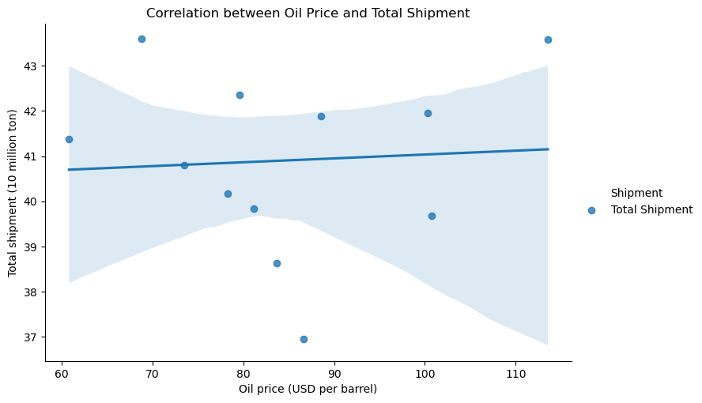

## B. Oil Price and Volumes of Transport Modes Trends 2021 to 2023

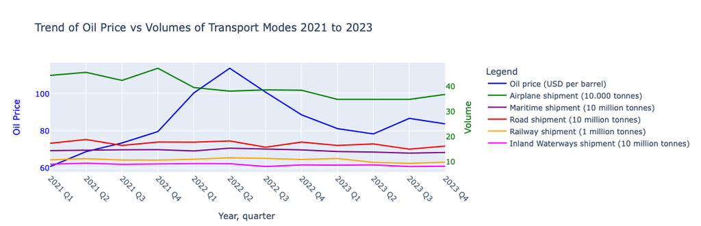

While oil prices experienced dramatic changes during this period, transport volumes were relatively stable overall. Airplane shipment showed some sensitivity to oil price spikes, while maritime, road, railway, and inland waterway transport exhibited greater resilience. This suggests that energy-efficient modes, such as rail and inland waterways has a possibly better ability to absorb or pass through fuel cost changes, underscore the importance of diversifying transport modes to ensure long-term resilience in the face of fluctuating energy cost.

To further support our claim, we examined the correlation between each transport mode's volume and oil prices with a scatter plot.

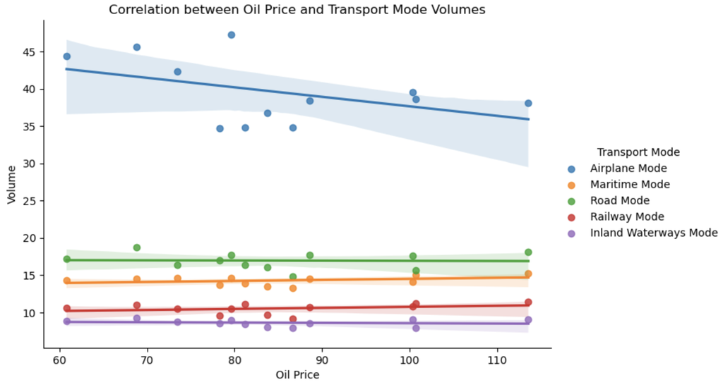

It can be seen that airplanes mode volumes has a negative correlation to the oil price, indicating that air cargo volume is indeed affected by oil price fluctuations. In contrast, other transport modes show minimal change, with Road and Inland Waterways mode appearing particularly flat while Railway and Maritime modes show a weak positive correlation. Air transport also shows the widest confidence intervals range, highlighting its sensitivity to oil price changes, whereas the confidence intervals for other transport modes show minimal impact from oil price fluctuations.

## C. Export Values by Country and Price Over Time

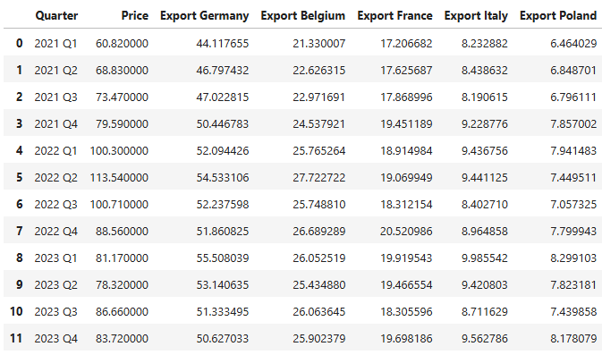

Considering independently the total export value from the Netherlands of these five EU countries, it underscores the importance of proximity and economic integration in shaping export patterns. Countries that are geographically closer and have stronger infrastructural ties to the Netherlands, such as Germany and Belgium, tend to command higher total export values. The export patterns also highlight the role of major EU economies (Germany and France) as primary trade partners, with smaller or more distant markets (Italy and Poland) playing a secondary role in Dutch export strategy.

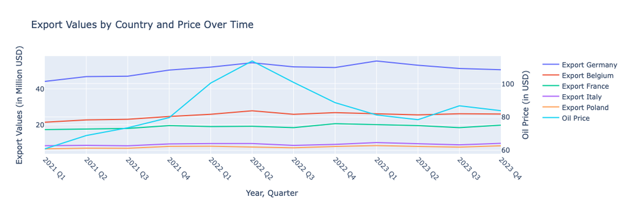

Overall, the data shows that oil prices had an initial influence on export values, particularly during the price surge from 2021 Q1 to 2022 Q2, but as prices began to fall, the export values stabilized. This indicates that while oil prices can affect trade dynamics in the short term, the long-term demand for Dutch exports is resilient, and not solely dependent on fluctuations in oil prices. The sustained demand, especially from Germany, Belgium, and France, highlights the strength of economic ties and suggests that these countries were able to absorb the price shocks without significantly reductheir import.

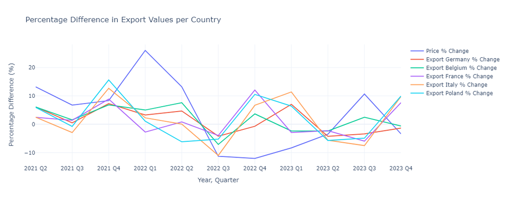

## D. Import Values by Country and Price Over Time

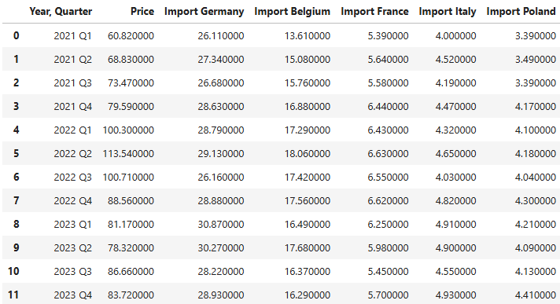

When examining the total import value to the Netherlands from these five EU countries individually, it highlights how economic integration significantly influence import trends. Similar to export value, countries that are geographically closer to the Netherlands and have stronger infrastructure connections, like Germany and Belgium, generally account for higher import values. This pattern also emphasizes the importance of major EU economies, such as Germany and France, as key trade partners, while smaller or more distant markets, like Italy and Poland, play a lesser role in the Dutch import strategy.

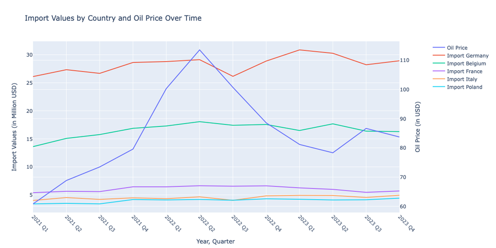

The data shows significant trends in import values to the Netherlands from five EU countries over the quarters from 2021 to 2023. In 2021, Germany emerged as the leading importer with values starting at 26.11 million USD in Q1 and gradually increasing to 28.63 million USD by Q4. Belgium followed with an initial value of 13.61 million USD in Q1, which rose steadily to 16.88 million USD in Q4. France's imports ranged from 5.39 million USD to 6.44 million USD, while Italy and Poland had lower values, starting at 4.00 million USD and 3.39 million USD respectively, with slight increases through the quarters.

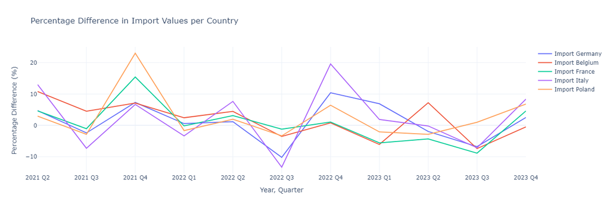

## Discussion

This research highlights the interconnectedness of geopolitical events, oil prices, and the logistics performance of a nation with a highly developed transport and trade infrastructure like the Netherlands. The volatility in oil prices, largely driven by the Russia-Ukraine conflict, had an immediate yet varied impacts on different sectors within the Dutch logistics performance. Notably, while oil price fluctuations are a significant factor, the data suggests that the Dutch logistics performance is resilient to a limited extent

The findings indicate that while some transport modes, such as airplanes, are more sensitive to oil price changes, other modes—especially rail and inland waterways—appear more resilient, likely due to higher energy efficiency and stability in their operational costs. The analysis of export and import values shows the depth of economic integration between the Netherlands and its key EU trade partners. The trade stability with Germany, Belgium, and France, despite fluctuating energy costs, emphasize the strength of these economic relationships.

The research also underscores the limitations of relying solely on oil prices as a determinant of logistics performance. The weak correlation between total shipment volumes and oil prices, coupled with the observed oil prices and export/import values over time, suggests that other macroeconomic factors, such as global demand cycles, supply chain constraints, and regional trade policies, play substantial roles. While this study provides insights into the impact of oil prices on logistics in the Netherlands, it is limited by the assumption of ceteris paribus, which may oversimplify the complex interdependencies within global trade networks.

## Datasets

- Crude oil prices:
  - Cushing, OK WTI Spot Price FOB (Dollars per Barrel) https://www.eia.gov/dnav/pet/hist/LeafHandler.ashx?n=pet&s=rwtc&f=m
  - Europe Brent Spot Price FOB (Dollars per Barrel) https://www.eia.gov/dnav/pet/hist/LeafHandler.ashx?n=PET&s=RBRTE&f=M
- Air transport: Air transport of goods by country https://ec.europa.eu/eurostat/databrowser/view/avia_gooc__custom_13108978/default/table?lang=en
- Inland waterway transport: Goods transport by inland waterways https://ec.europa.eu/eurostat/databrowser/view/iww_go_qnave__custom_13109022/default/table?lang=en
- Maritime transport: Sea transport of goods https://ec.europa.eu/eurostat/databrowser/view/mar_go_qm__custom_13109050/default/table?lang=en
- Railway transport: Goods transport by rail https://ec.europa.eu/eurostat/databrowser/view/rail_go_quartal__custom_13109085/default/table?lang=en
- Road transport: Goods transport by road https://ec.europa.eu/eurostat/databrowser/view/road_go_tq_tott__custom_13109107/default/table?lang=en
- International Trade (import and export) https://www.trademap.org/Index.aspx

## Reference

U.S. Energy Information and Administration 2022, *International - U.S. Energy Information and Administration (EIA)*, accessed 3 October 2024, https://www.eia.gov/international/rankings/world

Gas Transmission System Operator of Ukraine 2022, *Ukraine Stops Exporting Natural Gas*, accessed 3 October 2024, https://tsoua.com/en/news/ukraine-stops-exporting-natural-gas/

Inchauspe, J., Li, J., & Park, J. (2020) Seasonal patterns of global oil consumption: Implications for long term energy policy. Journal of Policy Modeling, 42(3), 536-556. https://doi.org/10.1016/j.jpolmod.2019.12.005

## Contribution Statement

Adi Putra Rukmananda: Background research, Oil Price and Shipment Quantity Trends visualisation, data modelling

Anh Tran: Background research, Export Values by Country and Price Over Time visualisation, data analysis

Fakhrinanisa Islah Birru: Background research, Import Values by Country and Price Over Time visualisation, data analysis

Rifan Fauzan Ghofir: Background research, Oil Price and Volumes of Transport Modes Trens visualisation, data modelling

Wilona Septyola Br Surbakti: Background research, Conceptualisation, Oil Price Surge visualisation, data analysis, data modelling